# StanTutorial

Loading the package

The package name is rstan (all lowercase), so we can use library(“rstan”) to load the package.

```r
#install.packages("rstan")
library(rstan) # observe startup messages
```

```r
rstan_options(auto_write = TRUE)
options(mc.cores = parallel::detectCores())
```

These options respectively allow you to automatically save a bare version of a compiled Stan program to the hard disk so that it does not need to be recompiled and to execute multiple Markov chains in parallel.

##References

Gelman, A., Carlin, J. B., Stern, H. S., and Rubin, D. B. (2003). Bayesian Data Analysis, CRC Press, London, 2nd Edition.

Stan Development Team. Stan Modeling Language User’s Guide and Reference Manual.

Gelfand, A. E., Hills S. E., Racine-Poon, A., and Smith A. F. M. (1990). “Illustration of

Bayesian Inference in Normal Data Models Using Gibbs Sampling”, Journal of the American Statistical Association, 85, 972-985.

## Tutorials:

https://cran.r-project.org/web/packages/rstan/vignettes/rstan.html

http://sumsar.net/files/posts/2017-01-15-bayesian-computation-with-stan-and-farmer-jons/stan_exercise.html

## Examples

And we can get a fit with the following R command. Note that the argument to file = should point to where the file is on your file system unless you have put it in the working directory of R in which case the below will work.

```r
# i.i.d. Bernoulli
y2 <- rbinom(20, 1, 0.4)
fit <- stan(file = 'Bernoulli.stan',
            data = list(N = length(y2), y = y2),
            iter = 1000, chains = 4)
```

```
## recompiling to avoid crashing R session
```

```
## Trying to compile a simple C file
```

[output not shown]

```r
print(fit)
```

```
## Inference for Stan model: anon_model.
## 4 chains, each with iter=1000; warmup=500; thin=1;
## post-warmup draws per chain=500, total post-warmup draws=2000.
##
##         mean se_mean   sd   2.5%    25%    50%    75%  97.5% n_eff Rhat
## theta   0.32    0.00 0.10   0.14   0.25   0.31   0.38   0.53   574 1.01
## lp__  -14.27    0.03 0.74 -16.42 -14.44 -13.98 -13.81 -13.76   722 1.00
##
## Samples were drawn using NUTS(diag_e) at Mon Apr  8 09:50:51 2024.
## For each parameter, n_eff is a crude measure of effective sample size,
## and Rhat is the potential scale reduction factor on split chains (at
## convergence, Rhat=1).
```

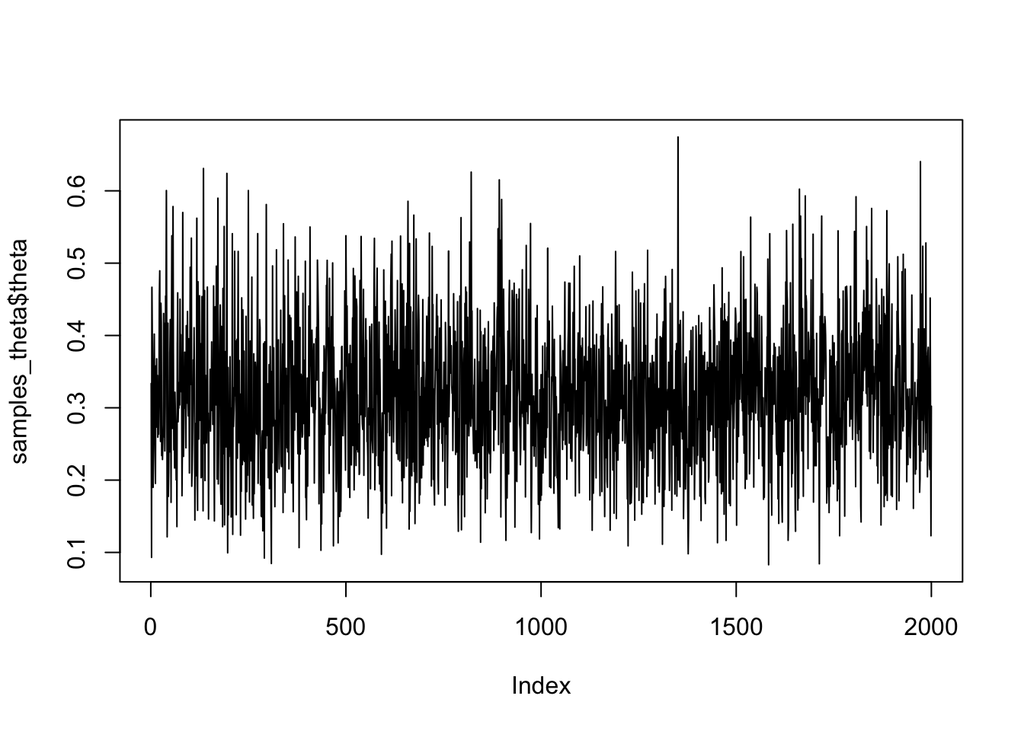

```r
samples_theta <- extract(fit)
plot(samples_theta$theta, type = "l")
```

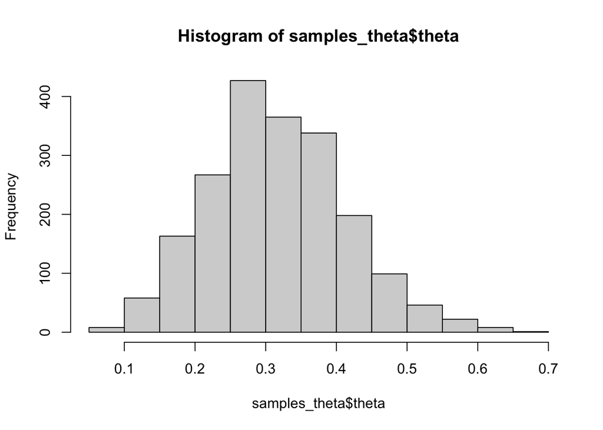

```r
hist(samples_theta$theta)
```

```
## ci_level: 0.8 (80% intervals)
```

```
## outer_level: 0.95 (95% intervals)
```

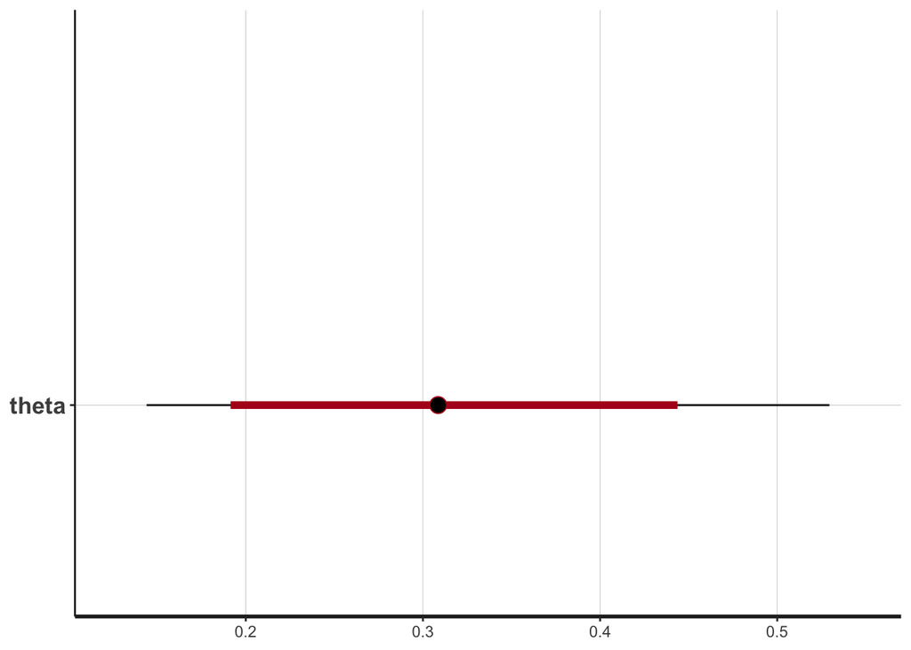

```r
plot(fit)
```

We can also specify a Stan model using a character string by using argument model_code of function stan instead. However, this is not recommended, as using a file allows you to use print statements and to dereference line numbers in error messages.

The object fit, returned from function stan is an S4 object of class stanfit. Methods such as print, plot, and pairs are associated with the fitted result so we can use the following code to check out the results in fit. print provides a summary for the parameter of the model as well as the log-posterior with name lp__ (see the following example output). For more methods and details of class stanfit, see the help of class stanfit.

In particular, we can use extract function on stanfit objects to obtain the samples. extract extracts samples from the stanfit object as a list of arrays for parameters of interest, or just an array. In addition, S3 functions as.array, as.matrix, and as.data.frame are defined for stanfit object (using help(“as.array.stanfit”) to check out the help document in R).

```r
# i.i.d. Bernoulli
bernoulli_code <- "
  data {
    int<lower=0> N;
    int<lower=0,upper=1> y[N];
  }
  parameters {
    real<lower=0,upper=1> theta;
  }
  model {
    theta ~ beta(1,1);
    for (n in 1:N)
      y[n] ~ bernoulli(theta);
    }
"
sm <- stan_model(model_code = bernoulli_code)
```

```
## Trying to compile a simple C file
```

[output not shown]

```r
y2 <- rbinom(20, 1, 0.4)
fit <- sampling(sm, data = list(N = 20, y = y2))
print(fit)
```

```
## Inference for Stan model: anon_model.
## 4 chains, each with iter=2000; warmup=1000; thin=1;
## post-warmup draws per chain=1000, total post-warmup draws=4000.
##
##         mean se_mean   sd   2.5%   25%    50%    75%  97.5% n_eff Rhat
## theta   0.27    0.00 0.09   0.11   0.2   0.26   0.33   0.47  1613    1
## lp__  -13.41    0.02 0.72 -15.42 -13.6 -13.14 -12.94 -12.89  1650    1
##
## Samples were drawn using NUTS(diag_e) at Mon Apr  8 09:51:32 2024.
## For each parameter, n_eff is a crude measure of effective sample size,
## and Rhat is the potential scale reduction factor on split chains (at
## convergence, Rhat=1).
```

```
## ci_level: 0.8 (80% intervals)
```

```
## outer_level: 0.95 (95% intervals)
```

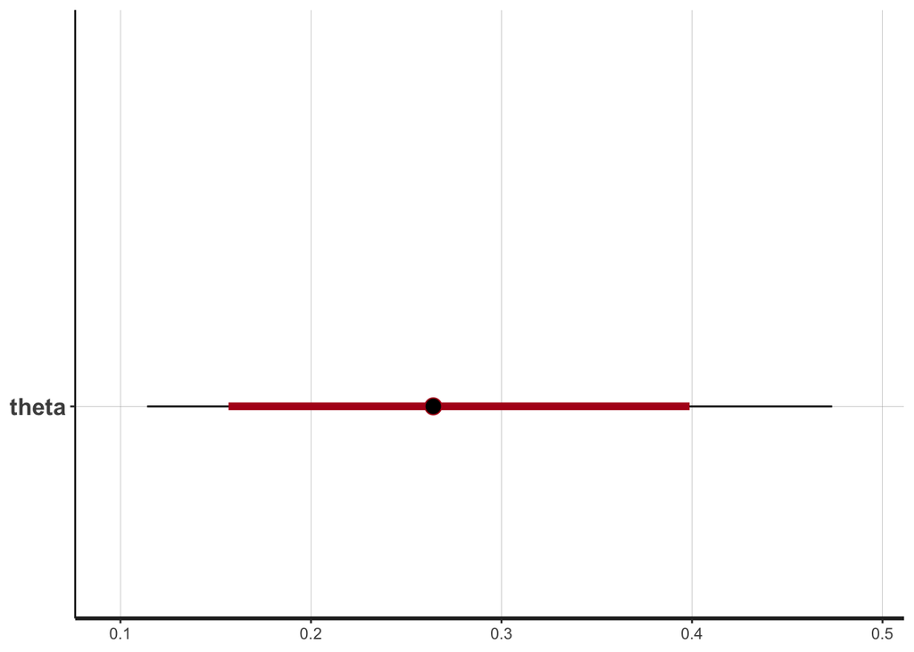

```r
plot(fit)
```

More details about RStan can be found in the documentation including the vignette of package rstan. For example, using help(stan) and help(“stanfit-class”) to check out the help for function stan and S4 class stanfit. And see Stan’s modeling language manual for details about Stan’s samplers, optimizers, and the Stan modeling language.

In addition, the Stan User’s Mailing list can be used to discuss the use of Stan, post examples or ask questions about (R)Stan. When help is needed, it is important to provide enough information such as the following:

model code in Stan modeling language data necessary R code dump of error message using verbose=TRUE and cores=1 when calling the stan function version of the C++ compiler, for example, using g++ -v to obtain this if gcc is used information about R by using function sessionInfo() in R

```r
# i.i.d. Gaussian
ocode <- "
  data {
    int<lower=1> N;
    real y[N];
  }
  parameters {
    real mu;
  }
  model {
    target += normal_lpdf(y | mu, 1);
  }
"
sm <- stan_model(model_code = ocode)
```

```
## Trying to compile a simple C file
```

[output not shown]

```r
y2 <- rnorm(20)
fit <- sampling(sm, data = list(N = 20, y = y2))
summary(fit)
```

```
## $summary
##               mean     se_mean        sd        2.5%         25%           50%
## mu     0.003420449 0.005668729 0.2239238  -0.4184774  -0.1498135   0.001722384
## lp__ -27.806360830 0.016223242 0.6960736 -29.7544708 -27.9912668 -27.536682172
##              75%       97.5%    n_eff    Rhat
## mu     0.1543142   0.4365143 1560.376 1.00254
## lp__ -27.3523568 -27.3054549 1840.920 1.00083
##
## $c_summary
## , , chains = chain:1
##
##          stats
## parameter          mean        sd        2.5%         25%           50%
##      mu     0.003527819 0.2311157  -0.4226825  -0.1538685  -0.006042701
##      lp__ -27.838675668 0.7639817 -29.9872606 -27.9860123 -27.556285460
##          stats
## parameter         75%       97.5%
##      mu     0.1636783   0.4873839
##      lp__ -27.3616256 -27.3056418
##
## , , chains = chain:2
##
##          stats
## parameter          mean        sd        2.5%         25%           50%
##      mu    -0.007725159 0.2201684  -0.4121389  -0.1610662  -0.006616693
##      lp__ -27.790789433 0.6745140 -29.5093813 -27.9980858 -27.528407790
##          stats
## parameter         75%       97.5%
##      mu     0.1436111   0.4186609
##      lp__ -27.3521189 -27.3055312
##
## , , chains = chain:3
##
##          stats
## parameter          mean        sd        2.5%         25%           50%
##      mu     0.008436646 0.2311386  -0.4272599  -0.1526104   0.008639988
##      lp__ -27.838934596 0.6755602 -29.6518344 -28.1055582 -27.556476018
##          stats
## parameter         75%       97.5%
##      mu     0.1676015   0.4335328
##      lp__ -27.3577626 -27.3054842
##
## , , chains = chain:4
##
##          stats
## parameter          mean        sd        2.5%        25%           50%
##      mu     0.009442488 0.2126467  -0.4102188  -0.132194   0.009733739
##      lp__ -27.757043623 0.6631176 -29.5810394 -27.884714 -27.499606234
##          stats
## parameter         75%       97.5%
##      mu     0.1466601   0.4296437
##      lp__ -27.3427656 -27.3052970
```

```r
samples_fit <- extract(fit)
```

```r
# Two coins
model_string <- "
data {

  int n1;
  int n2;

  int y1[n1];
  int y2[n2];
}

parameters {
  real<lower=0, upper=1> theta1;
  real<lower=0, upper=1> theta2;
}

model {
  theta1 ~ beta(1, 1);
  theta2 ~ beta(1, 1);
  y1 ~ bernoulli(theta1);
  y2 ~ bernoulli(theta2);
}

"

y1 <- c(0, 1, 0, 0, 0, 0, 1, 0, 0, 0)
y2 <- c(0, 0, 1, 1, 1, 0, 1, 1, 1, 0)
data_list <- list(y1 = y1, y2 = y2, n1 = length(y1), n2 = length(y2))

# Compiling and producing posterior samples from the model.
stan_samples <- stan(model_code = model_string, data = data_list)
```

```
## Trying to compile a simple C file
```

[output not shown]

```r
# Plotting and summarizing the posterior distribution
stan_samples
```

```
## Inference for Stan model: anon_model.
## 4 chains, each with iter=2000; warmup=1000; thin=1;
## post-warmup draws per chain=1000, total post-warmup draws=4000.
##
##          mean se_mean   sd   2.5%    25%    50%    75%  97.5% n_eff Rhat
## theta1   0.25    0.00 0.12   0.06   0.16   0.24   0.33   0.52  3347    1
## theta2   0.59    0.00 0.14   0.31   0.49   0.59   0.69   0.84  2975    1
## lp__   -15.96    0.02 1.05 -18.77 -16.35 -15.63 -15.21 -14.92  1776    1
##
## Samples were drawn using NUTS(diag_e) at Mon Apr  8 09:52:52 2024.
## For each parameter, n_eff is a crude measure of effective sample size,
## and Rhat is the potential scale reduction factor on split chains (at
## convergence, Rhat=1).
```

```
## ci_level: 0.8 (80% intervals)
```

```
## outer_level: 0.95 (95% intervals)
```

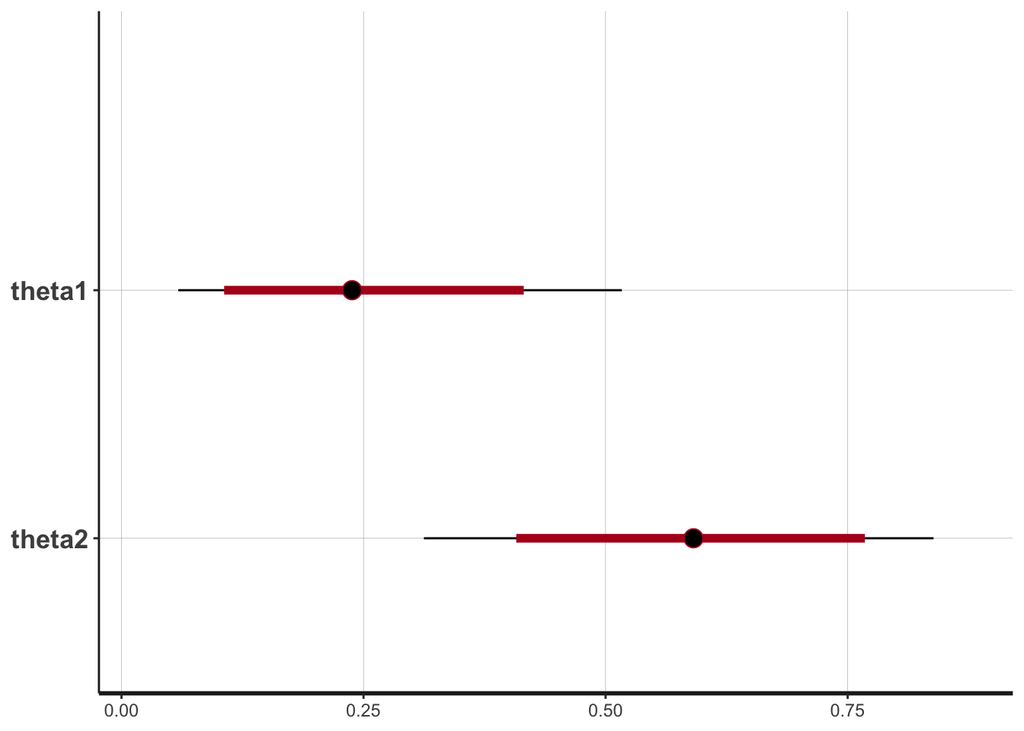

```r
plot(stan_samples)
```

# Practice Problem

Farmer Jons has a huge number of cows. Earlier this year he ran an experiment where he gave 10 cows medicine A and 10 medicine B and then measured whether they got sick (0) or not (1) during the summer season. Here is the resulting data:

```r
cowA <- c(0, 1, 0, 0, 0, 0, 1, 0, 0, 0)
cowB <- c(0, 0, 1, 1, 1, 0, 1, 1, 1, 0)
```

Jons now wants to know: How effective are the drugs? What is the evidence that medicine A is better or worse than medicine B?

Farmer Jons has a huge number of cows. Earlier this year he ran an experiment where he gave 10 cows a special diet that he had heard could make them produce more milk. He recorded the number of liters of milk from these “diet” cows and from 15 “normal” cows during one month. This is the data:

```r
diet_milk <- c(651, 679, 374, 601, 401, 609, 767, 709, 704, 679)
normal_milk <- c(798, 1139, 529, 609, 553, 743, 151, 544, 488, 555, 257, 692, 678, 675, 538)
```

Jons now wants to know: Was the diet any good, does it results in better milk production?

```r
model_string <- "
data {
  int<lower=0> n1;
  int<lower=0> n2;
  real y1[n1];
  real y2[n2];
}

parameters {
  real mu1;
  real<lower=0> sigma1;
  real mu2;
  real<lower=0> sigma2;
}

model {
  for(i in 1:n1 ) {
    y1[i] ~ normal(mu1, sigma1);
  }
  for(i in 1:n2 ) {
    y2[i] ~ normal(mu2, sigma2);
  }
}

generated quantities {
}
"
data_milk = list(n1 = length(diet_milk), y1 = diet_milk, n2 = length(normal_milk), y2 = normal_milk)
stan_samples <- stan(model_code = model_string, data = data_milk)
```

```
## Trying to compile a simple C file
```

[output not shown]

```r
# Plotting and summarizing the posterior distribution
stan_samples
```

```
## Inference for Stan model: anon_model.
## 4 chains, each with iter=2000; warmup=1000; thin=1;
## post-warmup draws per chain=1000, total post-warmup draws=4000.
##
##           mean se_mean    sd    2.5%     25%     50%     75%   97.5% n_eff Rhat
## mu1     619.23    1.09 52.25  519.49  587.27  618.85  649.91  722.57  2315    1
## sigma1  154.26    0.97 46.70   92.89  123.56  144.72  173.98  267.95  2300    1
## mu2     597.63    1.09 65.00  470.71  555.27  597.50  640.48  727.10  3547    1
## sigma2  249.89    1.03 55.14  169.75  210.51  241.72  279.17  381.13  2852    1
## lp__   -133.49    0.04  1.55 -137.33 -134.23 -133.11 -132.37 -131.54  1504    1
##
## Samples were drawn using NUTS(diag_e) at Mon Apr  8 09:53:33 2024.
## For each parameter, n_eff is a crude measure of effective sample size,
## and Rhat is the potential scale reduction factor on split chains (at
## convergence, Rhat=1).
```

```
## ci_level: 0.8 (80% intervals)
```

```
## outer_level: 0.95 (95% intervals)
```

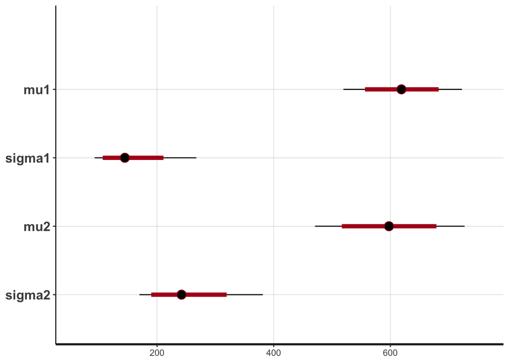

```r
plot(stan_samples)
```

He also has chickens. He tries different diets on them too with the hope that they will produce more eggs. Below is the number of eggs produced in one week by chickens on a diet and chickens eating normal chicken stuff:

```r
diet_eggs <- c(6, 4, 2, 3, 4, 3, 0, 4, 0, 6, 3)
normal_eggs <- c(4, 2, 1, 1, 2, 1, 2, 1, 3, 2, 1)
```

Jons now wants to know: Was the diet any good, does it result in the chickens producing more eggs?

```r
model_string <- "
data {
  int<lower=0> n1;
  int<lower=0> n2;
  int y1[n1];
  int y2[n2];
}

parameters {
  real<lower=0> lambda1;
  real<lower=0> lambda2;
}

model {
  for(i in 1:n1 ) {
    y1[i] ~ poisson(lambda1);
  }
  for(i in 1:n2 ) {
    y2[i] ~ poisson(lambda2);
  }
}

generated quantities {
}
"
data_eggs = list(n1 = length(diet_eggs), y1 = diet_eggs, n2 = length(normal_eggs), y2 = normal_eggs)
stan_samples <- stan(model_code = model_string, data = data_eggs)
```

```
## Trying to compile a simple C file
```

[output not shown]

```r
# Plotting and summarizing the posterior distribution
stan_samples
```

```
## Inference for Stan model: anon_model.
## 4 chains, each with iter=2000; warmup=1000; thin=1;
## post-warmup draws per chain=1000, total post-warmup draws=4000.
##
##          mean se_mean   sd  2.5%   25%   50%   75% 97.5% n_eff Rhat
## lambda1  3.26    0.01 0.55  2.24  2.87  3.22  3.60  4.44  2940    1
## lambda2  1.91    0.01 0.42  1.16  1.61  1.89  2.17  2.84  2927    1
## lp__    -1.79    0.03 1.06 -4.54 -2.21 -1.44 -1.03 -0.76  1477    1
##
## Samples were drawn using NUTS(diag_e) at Mon Apr  8 09:54:14 2024.
## For each parameter, n_eff is a crude measure of effective sample size,
## and Rhat is the potential scale reduction factor on split chains (at
## convergence, Rhat=1).
```

```
## ci_level: 0.8 (80% intervals)
```

```
## outer_level: 0.95 (95% intervals)
```

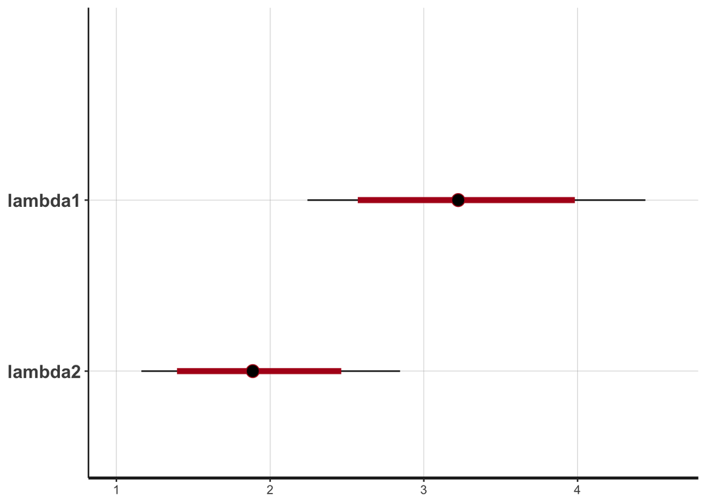

```r
plot(stan_samples)
```

Farmer Jons has a huge number of cows. He is wondering whether the amount of time a cow spends outside in the sunshine affects how much milk she produces. To test this he makes a controlled experiment where he picks out 20 cows and assigns each a number of hours she should spend outside each day. The experiment runs for a month and Jöns records the number of liters of milk each cow produces. Copy-n-paste the following into R and inspect the resulting data frame d.

```r
d <- data.frame(milk = c(685, 691, 476, 1151, 879, 725, 1190, 1107, 809, 539,
                         298, 805, 820, 498, 1026, 1217, 1177, 684, 1061, 834),
                hours = c(3, 7, 6, 10, 6, 5, 10, 11, 9, 3, 6, 6, 3, 5, 8, 11,
                          12, 9, 5, 5))
```

Using this data on hours of sunshine and resulting liters of milk Jons wants to know: Does sunshine affect milk production positively or negatively?

```r
model_string <- "
data {
  int<lower=0> n;
  real x[n];
  real y[n];
}

parameters {
  real<lower=0> beta0;
  real<lower=0> beta1;
  real<lower=0> sigma;
}

model {
  for(i in 1:n ) {
    y[i] ~ normal(beta0 + beta1 * x[i], sigma);
  }
}

generated quantities {
}
"
data_cows = list(n = length(d$milk), y = d$milk, x = d$hours)
stan_samples <- stan(model_code = model_string, data = data_cows)
```

```
## Trying to compile a simple C file
```

[output not shown]

```r
# Plotting and summarizing the posterior distribution
stan_samples
```

```
## Inference for Stan model: anon_model.
## 4 chains, each with iter=2000; warmup=1000; thin=1;
## post-warmup draws per chain=1000, total post-warmup draws=4000.
##
##          mean se_mean     sd    2.5%     25%     50%     75%   97.5% n_eff Rhat
## beta0  406.68    4.36 137.50  139.45  314.38  407.14  497.36  678.59   996 1.01
## beta1   60.97    0.57  18.19   24.21   48.82   61.06   73.47   95.68  1023 1.01
## sigma  222.84    0.96  39.79  159.95  194.80  216.78  246.36  318.16  1731 1.00
## lp__  -101.97    0.04   1.40 -105.58 -102.60 -101.60 -100.92 -100.36   993 1.00
##
## Samples were drawn using NUTS(diag_e) at Mon Apr  8 09:56:13 2024.
## For each parameter, n_eff is a crude measure of effective sample size,
## and Rhat is the potential scale reduction factor on split chains (at
## convergence, Rhat=1).
```

```
## ci_level: 0.8 (80% intervals)
```

```
## outer_level: 0.95 (95% intervals)
```

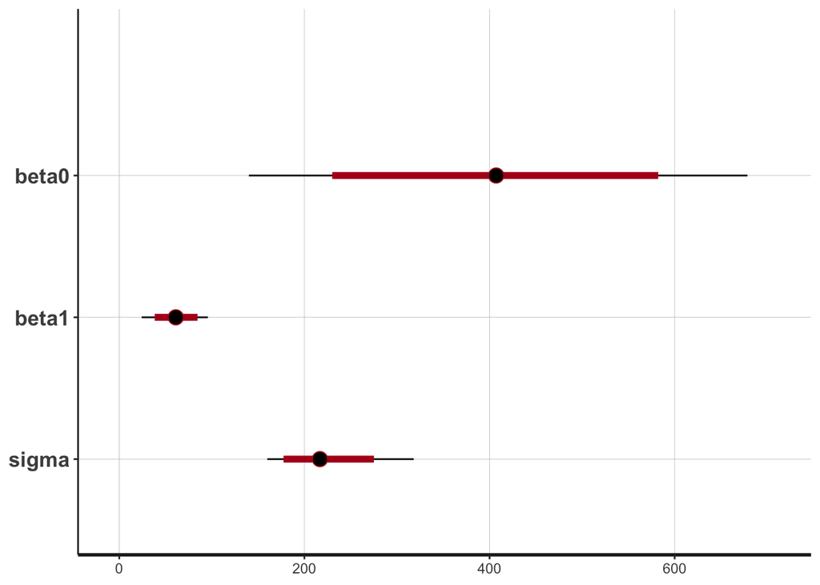

```r
plot(stan_samples)
```

Example: Eight Schools

This is an example in Section 5.5 of Gelman et al (2003), which studied coaching effects from eight schools. For simplicity, we call this example “eight schools.”

In this model, we let theta be transformed parameters of mu and eta instead of directly declaring theta as parameters. By parameterizing this way, the sampler will run more efficiently (see detailed explanation). We can prepare the data in R with:

```r
schools_dat <- list(J = 8,
                    y = c(28,  8, -3,  7, -1,  1, 18, 12),
                    sigma = c(15, 10, 16, 11,  9, 11, 10, 18))
```

And we can get a fit with the following R command. Note that the argument to file = should point to where the file is on your file system unless you have put it in the working directory of R in which case the below will work.

```r
fit <- stan(file = '8schools.stan', data = schools_dat,
            iter = 1000, chains = 4)
```

```
## Trying to compile a simple C file
```

[output not shown]

We can also specify a Stan model using a character string by using argument model_code of function stan instead. However, this is not recommended, as using a file allows you to use print statements and to dereference line numbers in error messages.

The object fit, returned from function stan is an S4 object of class stanfit. Methods such as print, plot, and pairs are associated with the fitted result so we can use the following code to check out the results in fit. print provides a summary for the parameter of the model as well as the log-posterior with name lp__ (see the following example output). For more methods and details of class stanfit, see the help of class stanfit.

In particular, we can use extract function on stanfit objects to obtain the samples. extract extracts samples from the stanfit object as a list of arrays for parameters of interest, or just an array. In addition, S3 functions as.array, as.matrix, and as.data.frame are defined for stanfit object (using help(“as.array.stanfit”) to check out the help document in R).

```r
print(fit)
```

```
## Inference for Stan model: anon_model.
## 4 chains, each with iter=1000; warmup=500; thin=1;
## post-warmup draws per chain=500, total post-warmup draws=2000.
##
##            mean se_mean   sd   2.5%    25%    50%    75%  97.5% n_eff Rhat
## mu         8.22    0.14 4.98  -1.31   4.84   8.25  11.51  18.30  1276 1.00
## tau        6.47    0.19 5.43   0.24   2.40   5.24   9.17  20.44   858 1.00
## eta[1]     0.36    0.02 0.92  -1.55  -0.23   0.40   0.99   2.14  1984 1.00
## eta[2]     0.01    0.02 0.87  -1.59  -0.59   0.02   0.58   1.72  1966 1.00
## eta[3]    -0.20    0.02 0.94  -2.04  -0.81  -0.20   0.41   1.67  2498 1.00
## eta[4]    -0.06    0.02 0.87  -1.76  -0.63  -0.07   0.50   1.66  1845 1.00
## eta[5]    -0.37    0.02 0.88  -1.96  -0.99  -0.40   0.19   1.48  1745 1.00
## eta[6]    -0.20    0.02 0.89  -1.89  -0.80  -0.22   0.36   1.61  2136 1.00
## eta[7]     0.32    0.02 0.91  -1.57  -0.28   0.36   0.94   2.02  1985 1.00
## eta[8]     0.08    0.02 0.95  -1.73  -0.55   0.09   0.71   1.92  2335 1.00
## theta[1]  11.53    0.21 8.24  -1.52   6.10  10.44  15.53  32.18  1572 1.00
## theta[2]   8.17    0.13 6.33  -3.83   4.13   7.97  12.23  20.94  2514 1.00
## theta[3]   6.46    0.18 7.58 -10.08   2.32   6.77  11.24  20.53  1843 1.00
## theta[4]   7.75    0.14 6.39  -4.98   3.76   7.78  11.89  20.63  1979 1.00
## theta[5]   5.19    0.14 6.43  -9.62   1.38   5.68   9.63  16.28  2197 1.00
## theta[6]   6.55    0.14 6.57  -7.23   2.62   6.57  10.86  19.10  2178 1.00
## theta[7]  10.74    0.15 6.88  -1.39   6.22  10.36  14.77  25.76  2017 1.00
## theta[8]   8.70    0.18 7.87  -6.33   4.00   8.30  13.11  26.16  1932 1.00
## lp__     -39.57    0.11 2.65 -45.29 -41.27 -39.24 -37.73 -35.00   619 1.01
##
## Samples were drawn using NUTS(diag_e) at Mon Apr  8 09:56:56 2024.
## For each parameter, n_eff is a crude measure of effective sample size,
## and Rhat is the potential scale reduction factor on split chains (at
## convergence, Rhat=1).
```

```
## 'pars' not specified. Showing first 10 parameters by default.
```

```
## ci_level: 0.8 (80% intervals)
```

```
## outer_level: 0.95 (95% intervals)
```

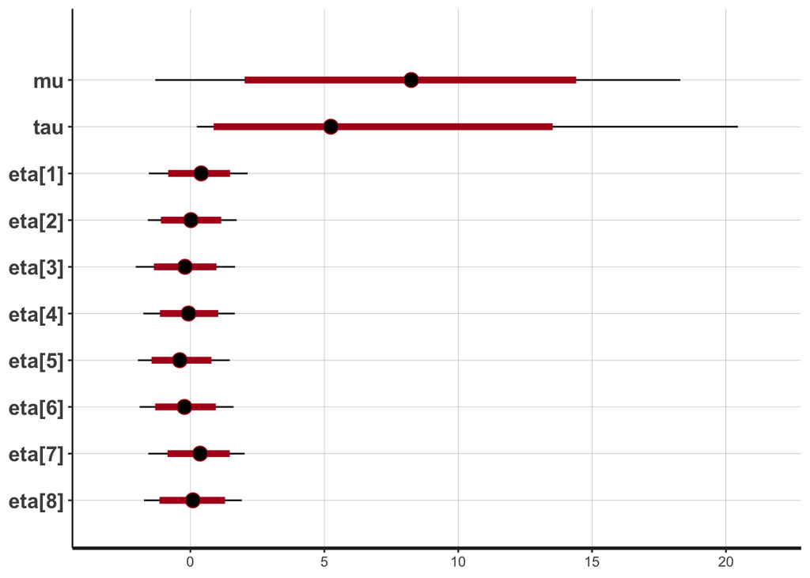

```r
plot(fit)
```

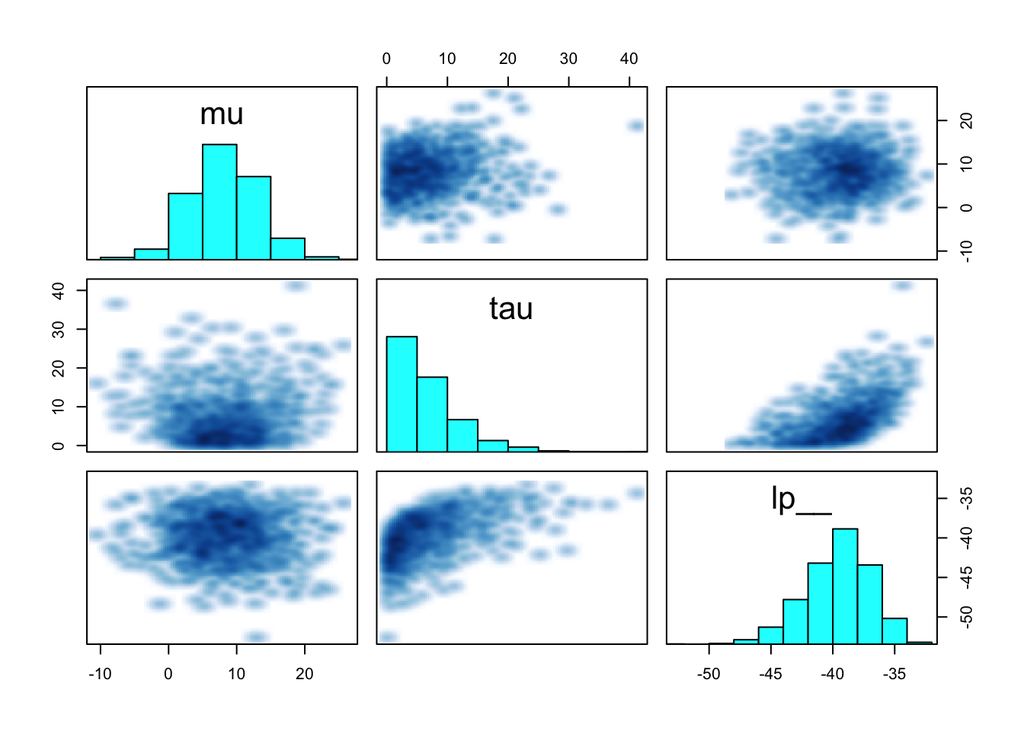

```r
pairs(fit, pars = c("mu", "tau", "lp__"))
```

```r
la <- extract(fit, permuted = TRUE) # return a list of arrays
mu <- la$mu

### return an array of three dimensions: iterations, chains, parameters
a <- extract(fit, permuted = FALSE)

### use S3 functions on stanfit objects
a2 <- as.array(fit)
m <- as.matrix(fit)
d <- as.data.frame(fit)
print(fit, digits = 1)
```

```
## Inference for Stan model: anon_model.
## 4 chains, each with iter=1000; warmup=500; thin=1;
## post-warmup draws per chain=500, total post-warmup draws=2000.
##
##           mean se_mean  sd  2.5%   25%   50%   75% 97.5% n_eff Rhat
## mu         8.2     0.1 5.0  -1.3   4.8   8.2  11.5  18.3  1276    1
## tau        6.5     0.2 5.4   0.2   2.4   5.2   9.2  20.4   858    1
## eta[1]     0.4     0.0 0.9  -1.5  -0.2   0.4   1.0   2.1  1984    1
## eta[2]     0.0     0.0 0.9  -1.6  -0.6   0.0   0.6   1.7  1966    1
## eta[3]    -0.2     0.0 0.9  -2.0  -0.8  -0.2   0.4   1.7  2498    1
## eta[4]    -0.1     0.0 0.9  -1.8  -0.6  -0.1   0.5   1.7  1845    1
## eta[5]    -0.4     0.0 0.9  -2.0  -1.0  -0.4   0.2   1.5  1745    1
## eta[6]    -0.2     0.0 0.9  -1.9  -0.8  -0.2   0.4   1.6  2136    1
## eta[7]     0.3     0.0 0.9  -1.6  -0.3   0.4   0.9   2.0  1985    1
## eta[8]     0.1     0.0 0.9  -1.7  -0.6   0.1   0.7   1.9  2335    1
## theta[1]  11.5     0.2 8.2  -1.5   6.1  10.4  15.5  32.2  1572    1
## theta[2]   8.2     0.1 6.3  -3.8   4.1   8.0  12.2  20.9  2514    1
## theta[3]   6.5     0.2 7.6 -10.1   2.3   6.8  11.2  20.5  1843    1
## theta[4]   7.7     0.1 6.4  -5.0   3.8   7.8  11.9  20.6  1979    1
## theta[5]   5.2     0.1 6.4  -9.6   1.4   5.7   9.6  16.3  2197    1
## theta[6]   6.5     0.1 6.6  -7.2   2.6   6.6  10.9  19.1  2178    1
## theta[7]  10.7     0.2 6.9  -1.4   6.2  10.4  14.8  25.8  2017    1
## theta[8]   8.7     0.2 7.9  -6.3   4.0   8.3  13.1  26.2  1932    1
## lp__     -39.6     0.1 2.6 -45.3 -41.3 -39.2 -37.7 -35.0   619    1
##
## Samples were drawn using NUTS(diag_e) at Mon Apr  8 09:56:56 2024.
## For each parameter, n_eff is a crude measure of effective sample size,
## and Rhat is the potential scale reduction factor on split chains (at
## convergence, Rhat=1).
```

In addition, as in BUGS (or JAGS), CmdStan (the command line interface to Stan) needs all the data to be in an R dump file. In the case we have this file, rstan provides function read_rdump to read all the data into an R list. For example, if we have a file named “8schools.rdump” that contains the following text in our working directory.

```r
J <- 8
y <- c(28,  8, -3,  7, -1,  1, 18, 12)
sigma <- c(15, 10, 16, 11,  9, 11, 10, 18)
fit <- stan(file = '8schools.stan', iter = 1000, chains = 4)
```

More details about RStan can be found in the documentation including the vignette of package rstan. For example, using help(stan) and help(“stanfit-class”) to check out the help for function stan and S4 class stanfit. And see Stan’s modeling language manual for details about Stan’s samplers, optimizers, and the Stan modeling language.

In addition, the Stan User’s Mailing list can be used to discuss the use of Stan, post examples or ask questions about (R)Stan. When help is needed, it is important to provide enough information such as the following:

model code in Stan modeling language data necessary R code dump of error message using verbose=TRUE and cores=1 when calling the stan function version of the C++ compiler, for example, using g++ -v to obtain this if gcc is used information about R by using function sessionInfo() in R